# Geomática para Ambientes - Tarefa 02

Vítor Ferreira

15/12/2023

## Introdução

O campo magnético da Terra não é homogêneo, apresentando variações espaciais e variações temporais. De acordo com à posição do nosso planeta no sistema solar, o campo magnético sofre alterações periódicas (diárias e anuais) relacionadas com a aproximação e afastamento do Sol. Existem ainda perturbações não periódicas de origem externa e de origem interna.

## Objetivo

O objetivo da segunda tarefa prática é avaliar um método de determinar e caracterizar a declinação magnética de forma local e global comparando as gerações 12th e 13th do International Geomagnetic Reference Field (IGRF).

## Habilitando Pacotes no R

O pacote oce lida com uma ampla variedade de tarefas que surgem na análise de dados oceanográficos.O pacote oce é utilizado como biblioteca para importar e mapear os dados no R. O pacote oce é carregado com a função library.

```r
library("oce")
```

## Declinação magnética atualmente em Lavras

```r
lavras <- magneticField(-45.0014, -21.2485, Sys.Date())
```

```r
bh <- magneticField(-19.9167,-43.9346, Sys.Date())
varginha <- magneticField( -21.5567,-45.4369, Sys.Date())
```

## Mapa mundial da Declinação

O mapa mundial da declinação no ano 2000 é realizado a partir de funções do pacote oce. Num primeiro momento as fronteiras de países são obtidas a partir de dados pré-existentes com a função data. As funções par e mapPlot são utilizadas para mapear os dados com uma projeção cartográfica “+proj=robin”.

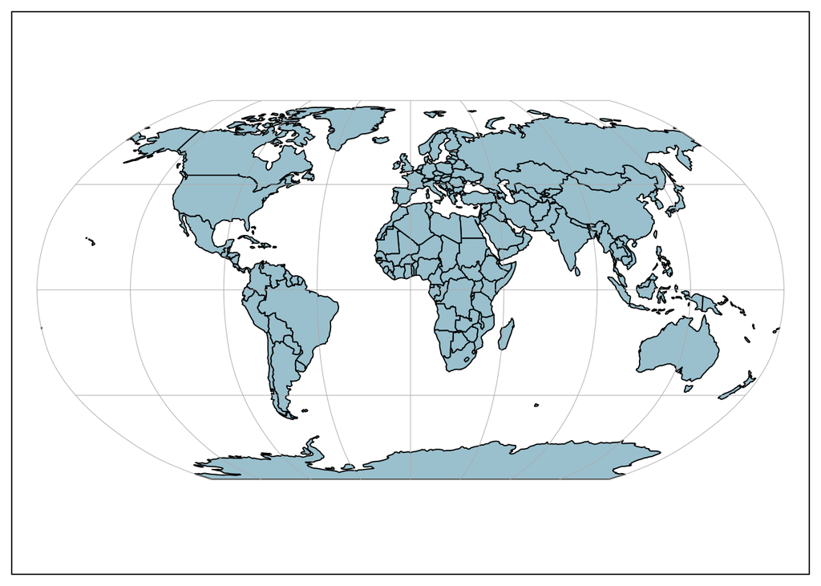

```r
data(coastlineWorld)
par(mar=rep(0.5, 4))
mapPlot(coastlineWorld, projection="+proj=robin", col="lightblue3")
```

## Matriz de Declinação

Uma função é utilizada para construir uma matriz de declinação magnética para valores de longitude e latitude mundiais com a função magneticField. A função outer organiza os dados em um objeto de classe matrix array.

```r
lon <- seq(-180, 180)
lat <- seq(-90, 90)
dec2000 <- function(lon, lat) {
  magneticField(lon, lat, 2000)$declination
}
dec <- outer(lon, lat, dec2000)
```

## Mapeamento do Contorno

O mapeamento de contornos é realizado a partir da função mapContour.

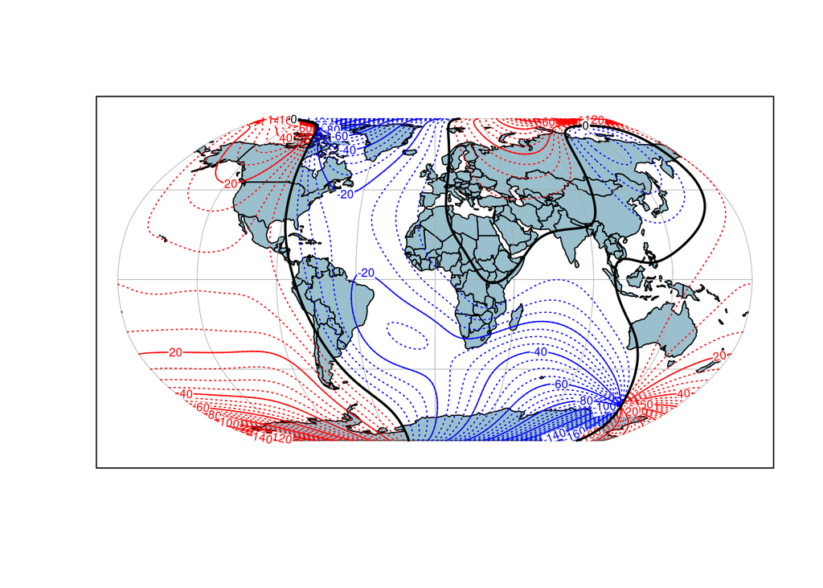

```r
mapPlot(coastlineWorld, projection="+proj=robin", col="lightblue3")
mapContour(lon, lat, dec, col="blue", levels=seq(-180, -5, 5),
           lty=3, drawlabels=FALSE)
mapContour(lon, lat, dec, col="blue", levels=seq(-180, -20, 20))
mapContour(lon, lat, dec, col="red", levels=seq(5, 180, 5),
           lty=3, drawlabels=FALSE)
mapContour(lon, lat, dec, col="red", levels=seq(20, 180, 20))
mapContour(lon, lat, dec, levels=180, col="black", lwd=2, drawlabels=FALSE)
mapContour(lon, lat, dec, levels=0, col="black", lwd=2)
```

## Diferença de declinação entre as versões IGRF 12 e 13

```r
lon <- seq(-180, 180)
lat <- seq(-90, 90)
decDiff <- function(lon, lat) {
    old <- magneticField(lon, lat, 2020, version=13)$declination
    new <- magneticField(lon, lat, 2020, version=12)$declination
    new - old
}
decDiff <- outer(lon, lat, decDiff)
decDiff <- ifelse(decDiff > 180, decDiff - 360, decDiff)
```

## Estatística

A estatística t é utilizada para avaliar a significância da diferença entre as versões IGRF 12 e 13. Os resultados são altamente significativos de acordo com o p-valor com intervalo de confiança a 95% de probabilidade entre -0.10399320 e -0.08683188 e média -0.09541254.

```r
t.test(decDiff)
```

```
##
##  One Sample t-test
##
## data:  decDiff
## t = -21.794, df = 65340, p-value < 2.2e-16
## alternative hypothesis: true mean is not equal to 0
## 95 percent confidence interval:
##  -0.10399320 -0.08683188
## sample estimates:
##   mean of x
## -0.09541254
```

## Histograma

Diferenças entre as versões IGRF, é possível constatar pequenas diferenças entre as versões IGRF 12 e 13.

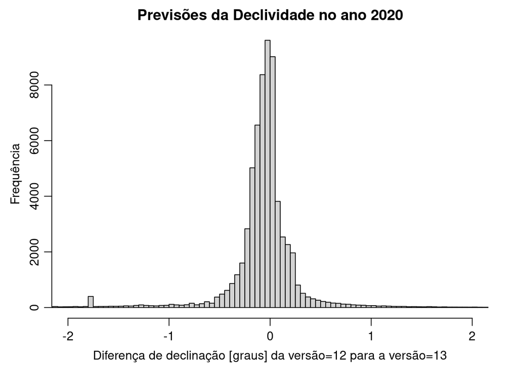

```r
par(mar=c(3.5, 3.5, 2, 2), mgp=c(2, 0.7, 0))
hist(decDiff, breaks=seq(-180, 180, 0.05), xlim=c(-2, 2),
       xlab="Diferença de declinação [graus] da versão=12 para a versão=13",
     ylab="Frequência",
     main="Previsões da Declividade no ano 2020")
```

```r
print(quantile(decDiff, c(0.025, 0.975)))
```

```
##       2.5%      97.5%
## -1.6695352  0.7159345
```

```r
#    2.5%      97.5%
#-1.6695352  0.7159345
```

## Mapeamento Colorido

Através da função imagep do pacote oce é possível mapear os resultados de diferenças de declinação magnética entre as versões IGRF 12 e 13 com uma paleta colorida.

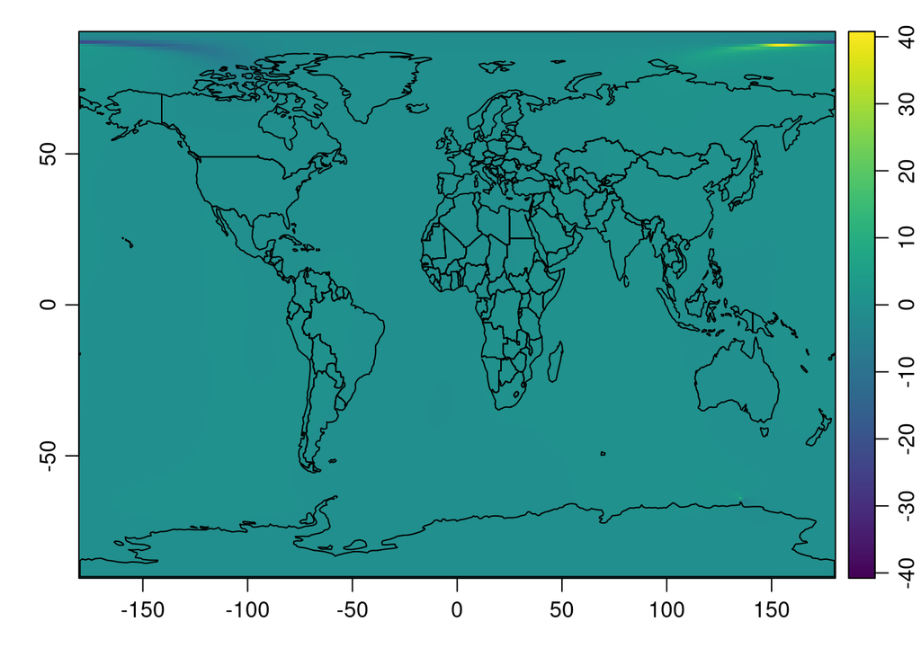

```r
imagep(lon,lat,decDiff, zlim=c(-1,1)*max(abs(decDiff)))
lines(coastlineWorld[["longitude"]], coastlineWorld[["latitude"]])
```

As maiores diferenças se deram latitudes elevadas

## Referência

Dan Kelley and Clark Richards (2023). oce: Analysis of Oceanographic Data. R package version 1.8-2. https://CRAN.R-project.org/package=oce

Dan Kelley, Clark Richards and WG127 SCOR/IAPSO (2022). gsw: Gibbs Sea Water Functions. R package version 1.1-1. https://CRAN.R-project.org/package=gsw